# Data Preprocessing

## Importing Libraries

```python
# pip install ucimlrepo
```

```python
#Importing libraries
import pandas as pd
from ucimlrepo import fetch_ucirepo
from sklearn.preprocessing import StandardScaler
import numpy as np
import matplotlib.pyplot as plt
from scipy.stats import skew
import seaborn as sns
from statsmodels.stats.outliers_influence import variance_inflation_factor
from scipy.spatial.distance import mahalanobis
from scipy.stats import chi2

pd.set_option('display.max_rows', None)  # To display all rows
pd.set_option('display.max_columns', None)  # To display all columns
```

## Description of Features

```python
data_dict = {
    "Variable Name": ["age", "sex", "chest-pain", "rest-bp", "serum-chol", "fasting-blood-sugar",
                      "electrocardiographic", "max-heart-rate", "angina", "oldpeak", "slope",
                      "major-vessels", "thal", "heart-disease"],
    "Type": ["Continuous", "Binary", "Categorical", "Continuous", "Continuous", "Binary",
             "Categorical", "Continuous", "Binary", "Continuous", "Integer", "Continuous",
             "Categorical", "Integer"],
    "Description": ["Age", "Sex", "chest pain type", "resting blood pressure", "serum cholesterol",
                    "fasting blood sugar > 120 mg/dl", "resting electrocardiographic results",
                    "maximum heart rate achieved", "exercise induced angina",
                    "oldpeak = ST depression induced by exercise relative to rest",
                    "the slope of the peak exercise ST segment",
                    "number of major vessels (0-3) colored by fluoroscopy",
                    "thal: 3 = normal; 6 = fixed defect; 7 = reversible defect", ""],
    "Description": ["age", "0 = female, 1 = male", "chest pain type", "resting blood pressure", "serum cholesterol",
                    "fasting blood sugar > 120 mg/dl", "resting electrocardiographic results",
                    "maximum heart rate achieved", "exercise induced angina",
                    "oldpeak = ST depression induced by exercise relative to rest",
                    "the slope of the peak exercise ST segment",
                    "number of major vessels (0-3) colored by fluoroscopy",
                    "thal: 3 = normal; 6 = fixed defect; 7 = reversible defect", "0 = absence of heart disease, 1 = presence of heart disease"],
    "Units": ["", "", "", "mmHg", "mg/dL", "", "", "", "", "", "", "", "", ""]
}

pd.DataFrame(data_dict)
```

|  | Variable Name | Type | Description | Units |
| --- | --- | --- | --- | --- |
| 0 | age | Continuous | age |  |
| 1 | sex | Binary | 0 = female, 1 = male |  |
| 2 | chest-pain | Categorical | chest pain type |  |
| 3 | rest-bp | Continuous | resting blood pressure | mmHg |
| 4 | serum-chol | Continuous | serum cholesterol | mg/dL |
| 5 | fasting-blood-sugar | Binary | fasting blood sugar > 120 mg/dl |  |
| 6 | electrocardiographic | Categorical | resting electrocardiographic results |  |
| 7 | max-heart-rate | Continuous | maximum heart rate achieved |  |
| 8 | angina | Binary | exercise induced angina |  |
| 9 | oldpeak | Continuous | oldpeak = ST depression induced by exercise re... |  |
| 10 | slope | Integer | the slope of the peak exercise ST segment |  |
| 11 | major-vessels | Continuous | number of major vessels (0-3) colored by fluor... |  |
| 12 | thal | Categorical | thal: 3 = normal; 6 = fixed defect; 7 = revers... |  |
| 13 | heart-disease | Integer | 0 = absence of heart disease, 1 = presence of ... |  |

```python
# fetch dataset
statlog_heart = fetch_ucirepo(id=145)

# data (as pandas dataframes)
X = statlog_heart.data.features
y = statlog_heart.data.targets
```

```python
# Combining features and target into one DataFrame
data = pd.concat([X, y], axis=1)

data['heart-disease'] = data['heart-disease'].replace({1: 0, 2: 1})

# Checking the head of DataFrame
data.head()
```

|  | age | sex | chest-pain | rest-bp | serum-chol | fasting-blood-sugar | electrocardiographic | max-heart-rate | angina | oldpeak | slope | major-vessels | thal | heart-disease |
| --- | --- | --- | --- | --- | --- | --- | --- | --- | --- | --- | --- | --- | --- | --- |
| 0 | 70.0 | 1.0 | 4.0 | 130.0 | 322.0 | 0.0 | 2.0 | 109.0 | 0.0 | 2.4 | 2.0 | 3.0 | 3.0 | 1 |
| 1 | 67.0 | 0.0 | 3.0 | 115.0 | 564.0 | 0.0 | 2.0 | 160.0 | 0.0 | 1.6 | 2.0 | 0.0 | 7.0 | 0 |
| 2 | 57.0 | 1.0 | 2.0 | 124.0 | 261.0 | 0.0 | 0.0 | 141.0 | 0.0 | 0.3 | 1.0 | 0.0 | 7.0 | 1 |
| 3 | 64.0 | 1.0 | 4.0 | 128.0 | 263.0 | 0.0 | 0.0 | 105.0 | 1.0 | 0.2 | 2.0 | 1.0 | 7.0 | 0 |
| 4 | 74.0 | 0.0 | 2.0 | 120.0 | 269.0 | 0.0 | 2.0 | 121.0 | 1.0 | 0.2 | 1.0 | 1.0 | 3.0 | 0 |

## Checking for Missing Values

First we are going to check the presence of missing values in the dataset.

```python
def Missing_Values(data):
    var_name = []
    data_type = []
    total_value = []
    total_missing_value = []
    missing_value_pct = []
    unique_value = []
    total_unique_value = []


    for col in data.columns:
        var_name.append(col)
        data_type.append(data[col].dtype)
        total_value.append(data[col].shape[0])
        total_missing_value.append(data[col].isnull().sum())
        missing_value_pct.append(round(data[col].isnull().sum()/data[col].shape[0],3))
        unique_value.append(data[col].unique())
        total_unique_value.append(len(data[col].unique()))

    missing_data=pd.DataFrame({"Variable":var_name,\
                               "Data_Type":data_type,\
                               "No_Total_Value":total_value,\
                               "No_Total_Missing_Value":total_missing_value,\
                               "Proportion_Missing_Value":missing_value_pct,\
                               "Unique_Value":unique_value,\
                               "Total_Unique_Value":total_unique_value
                              })

    missing_data = missing_data.set_index("Variable")
    return missing_data.sort_values("No_Total_Missing_Value",ascending=False)

Missing_Values(data)
```

| Variable | Data_Type | No_Total_Value | No_Total_Missing_Value | Proportion_Missing_Value | Unique_Value | Total_Unique_Value |
| --- | --- | --- | --- | --- | --- | --- |
| age | float64 | 270 | 0 | 0.0 | [70.0, 67.0, 57.0, 64.0, 74.0, 65.0, 56.0, 59.... | 41 |
| sex | float64 | 270 | 0 | 0.0 | [1.0, 0.0] | 2 |
| chest-pain | float64 | 270 | 0 | 0.0 | [4.0, 3.0, 2.0, 1.0] | 4 |
| rest-bp | float64 | 270 | 0 | 0.0 | [130.0, 115.0, 124.0, 128.0, 120.0, 110.0, 140... | 47 |
| serum-chol | float64 | 270 | 0 | 0.0 | [322.0, 564.0, 261.0, 263.0, 269.0, 177.0, 256... | 144 |
| fasting-blood-sugar | float64 | 270 | 0 | 0.0 | [0.0, 1.0] | 2 |
| electrocardiographic | float64 | 270 | 0 | 0.0 | [2.0, 0.0, 1.0] | 3 |
| max-heart-rate | float64 | 270 | 0 | 0.0 | [109.0, 160.0, 141.0, 105.0, 121.0, 140.0, 142... | 90 |
| angina | float64 | 270 | 0 | 0.0 | [0.0, 1.0] | 2 |
| oldpeak | float64 | 270 | 0 | 0.0 | [2.4, 1.6, 0.3, 0.2, 0.4, 0.6, 1.2, 4.0, 0.5, ... | 39 |
| slope | float64 | 270 | 0 | 0.0 | [2.0, 1.0, 3.0] | 3 |
| major-vessels | float64 | 270 | 0 | 0.0 | [3.0, 0.0, 1.0, 2.0] | 4 |
| thal | float64 | 270 | 0 | 0.0 | [3.0, 7.0, 6.0] | 3 |
| heart-disease | int64 | 270 | 0 | 0.0 | [1, 0] | 2 |

There is no missing value in the dataset, therefore for the EDA we are going to check whether each feature fall within the valid range, the distribution of each feature, followed by bivariate analysis.

## Exploratory Data Analysis

### 'age' Feature

```python
data['age'].describe()
```

```
count    270.000000
mean      54.433333
std        9.109067
min       29.000000
25%       48.000000
50%       55.000000
75%       61.000000
max       77.000000
Name: age, dtype: float64
```

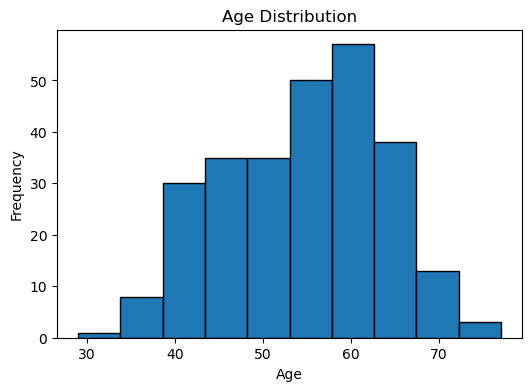

```python
# Draw histogram
plt.figure(figsize=(6, 4))
plt.hist(data['age'], bins=10, edgecolor='black')
plt.title('Age Distribution')
plt.xlabel('Age')
plt.ylabel('Frequency')
plt.show()
```

```python
# Skewness test
skew(data['age'])
```

```
-0.16270484746689945
```

The distribution for **age** is skewed slightly to the left. The age of the patients ranges from 29 to 77 years old, with most patients falling between 50 and 70 years of age. All observations fall within a valid range.

### 'sex' Feature

```python
data['sex'].value_counts(normalize=True)
```

```
sex
1.0    0.677778
0.0    0.322222
Name: proportion, dtype: float64
```

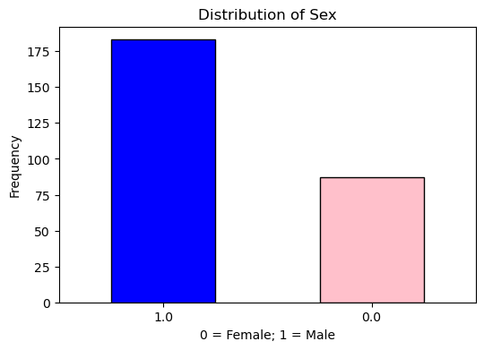

```python
plt.figure(figsize=(6, 4))
data['sex'].value_counts().plot(kind='bar', color=['blue', 'pink'], edgecolor='black')
plt.title('Distribution of Sex')
plt.xlabel('0 = Female; 1 = Male')
plt.ylabel('Frequency')
plt.xticks(rotation=0)
plt.show()
```

The dataset comprises 68% male patients and 32% female patients.

### 'chest-pain' Feature

```python
data['chest-pain'].value_counts(normalize=True)
```

```
chest-pain
4.0    0.477778
3.0    0.292593
2.0    0.155556
1.0    0.074074
Name: proportion, dtype: float64
```

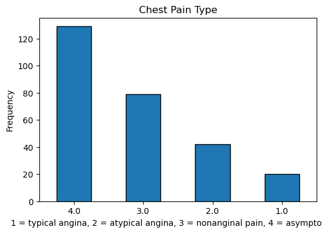

```python
plt.figure(figsize=(6, 4))
data['chest-pain'].value_counts().plot(kind='bar', edgecolor='black')
plt.title('Chest Pain Type')
plt.xlabel('1 = typical angina, 2 = atypical angina, 3 = nonanginal pain, 4 = asymptomatic')
plt.ylabel('Frequency')
plt.xticks(rotation=0)
plt.show()
```

Chest pain type is composed of 4 categories:

1. **Typical Angina**: characterized by predictable chest discomfort or pressure, often triggered by physical exertion or stress
2. **Atypical Angina**: presents with symptoms that do not fit the classic description of angina; pain may be unrelated to physical activity and diffuse
3. **Nonanginal Pain**: chest pain that is less likely related to heart disease, caused by other conditions such as gastrointestinal issues or musculoskeletal problems, and does not follow a predictable pattern
4. **Asymptomatic**: absense of chest pain symptoms despite the presence of heart disease, typically detected through tests

The most common type of chest pain is **asymptomatic**, comprising roughly half of the dataset, followed by nonanginal pain, atypical angina, and typical angina.

### 'rest-bp' Feature

```python
data['rest-bp'].describe()
```

```
count    270.000000
mean     131.344444
std       17.861608
min       94.000000
25%      120.000000
50%      130.000000
75%      140.000000
max      200.000000
Name: rest-bp, dtype: float64
```

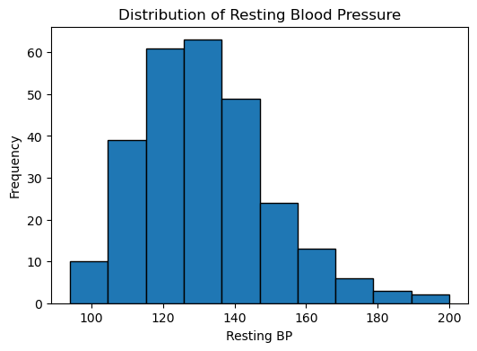

```python
# Draw histogram
plt.figure(figsize=(6, 4))
plt.hist(data['rest-bp'], bins=10, edgecolor='black')
plt.title('Distribution of Resting Blood Pressure')
plt.xlabel('Resting BP')
plt.ylabel('Frequency')
plt.show()
```

Resting blood pressure (BP) is slightly skewed to the right and ranges from 94 to 200. The majority of the patients have a resting BP between 120 and 140.

### 'serum-chol' Feature

```python
data['serum-chol'].describe()
```

```
count    270.000000
mean     249.659259
std       51.686237
min      126.000000
25%      213.000000
50%      245.000000
75%      280.000000
max      564.000000
Name: serum-chol, dtype: float64
```

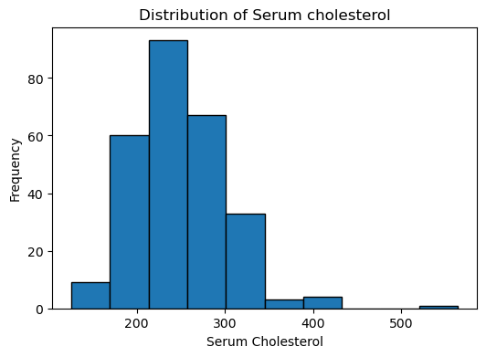

```python
# Draw histogram
plt.figure(figsize=(6, 4))
plt.hist(data['serum-chol'], bins=10, edgecolor='black')
plt.title('Distribution of Serum cholesterol')
plt.xlabel('Serum Cholesterol')
plt.ylabel('Frequency')
plt.show()
```

The distribution of serum cholesterol is slightly right-skewed with some outliers present, ranging from 126 to 564 mg/dL. Most values fall between 200 and 280 mg/dL.

### 'fasting-blood-sugar' Feature

```python
data['fasting-blood-sugar'].value_counts(normalize=True)
```

```
fasting-blood-sugar
0.0    0.851852
1.0    0.148148
Name: proportion, dtype: float64
```

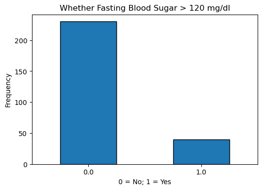

```python
plt.figure(figsize=(6, 4))
data['fasting-blood-sugar'].value_counts().plot(kind='bar', edgecolor='black')
plt.title('Whether Fasting Blood Sugar > 120 mg/dl')
plt.xlabel('0 = No; 1 = Yes')
plt.ylabel('Frequency')
plt.xticks(rotation=0)
plt.show()
```

There are 2 possible fasting blood sugar classes, 0 or 1, with 0 indicating fasting blood sugar levels less than or equal to 120 mg/dL, and 1 indicating fasting blood sugar levels greater than 120 mg/dL. The bar chart indicates that most patients (85%) do not have elevated fasting blood sugar levels above the 120 mg/dL threshold.

### 'electrocardiographic' Feature

```python
data['electrocardiographic'].value_counts(normalize=True)
```

```
electrocardiographic
2.0    0.507407
0.0    0.485185
1.0    0.007407
Name: proportion, dtype: float64
```

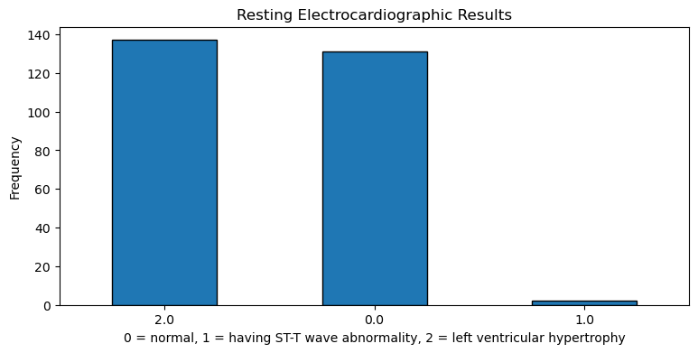

```python
plt.figure(figsize=(9, 4))
data['electrocardiographic'].value_counts().plot(kind='bar', edgecolor='black')
plt.title('Resting Electrocardiographic Results')
plt.xlabel('0 = normal, 1 = having ST-T wave abnormality, 2 = left ventricular hypertrophy')
plt.ylabel('Frequency')
plt.xticks(rotation=0)
plt.show()
```

The bar chart shows the distribution of patients based on their resting electrocardiographic results, categorized as follows:

- 0: indicates that the patient has normal resting electrocardiographic results, with no significant abnormalities detected
- 1: represents patients with ST-T wave abnormalities, indicative of various cardiovascular diseases
- 2: indicates the presence of left ventricular hypertrophy, which refers to the thickening of the walls of the heart’s left ventricle, often due to high blood pressure or other cardiovascular conditions

Most patients have either normal results or left ventricular hypertrophy.

### 'max-heart-rate' Feature

```python
data['max-heart-rate'].describe()
```

```
count    270.000000
mean     149.677778
std       23.165717
min       71.000000
25%      133.000000
50%      153.500000
75%      166.000000
max      202.000000
Name: max-heart-rate, dtype: float64
```

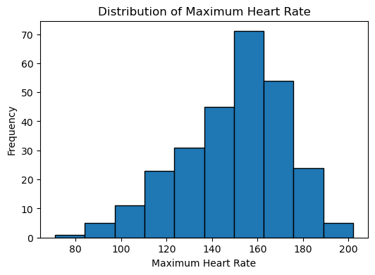

```python
# Draw histogram
plt.figure(figsize=(6, 4))
plt.hist(data['max-heart-rate'], bins=10, edgecolor='black')
plt.title('Distribution of Maximum Heart Rate')
plt.xlabel('Maximum Heart Rate')
plt.ylabel('Frequency')
plt.show()
```

```python
# Skewness test
skew(data['max-heart-rate'])
```

```
-0.5248002761623585
```

The distribution for **max-heart-rate** is left skewed, with all observations falling within a valid range. The maximum heart rate of patients falls between 71 and 202, with most patients having a maximum heart rate between 133 and 166.

### 'angina' Feature

```python
data['angina'].value_counts(normalize=True)
```

```
angina
0.0    0.67037
1.0    0.32963
Name: proportion, dtype: float64
```

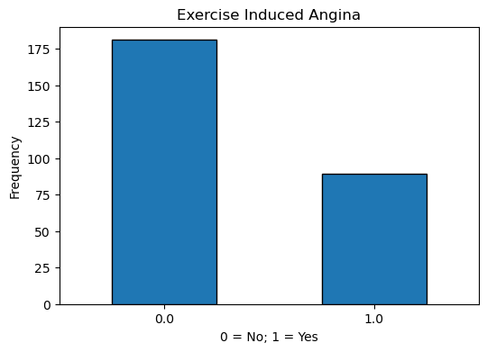

```python
plt.figure(figsize=(6, 4))
data['angina'].value_counts().plot(kind='bar', edgecolor='black')
plt.title('Exercise Induced Angina')
plt.xlabel('0 = No; 1 = Yes')
plt.ylabel('Frequency')
plt.xticks(rotation=0)
plt.show()
```

Exercise-induced angina refers to the discomfort that occurs during physical activity or exertion, which typically arises when the heart muscle does not receive enough oxygen-rich blood due to narrowed or blocked coronary arteries. 67% of the patients do not experience exercise-induced angina, whereas 33% do.

### 'oldpeak' Feature

```python
data['oldpeak'].describe()
```

```
count    270.00000
mean       1.05000
std        1.14521
min        0.00000
25%        0.00000
50%        0.80000
75%        1.60000
max        6.20000
Name: oldpeak, dtype: float64
```

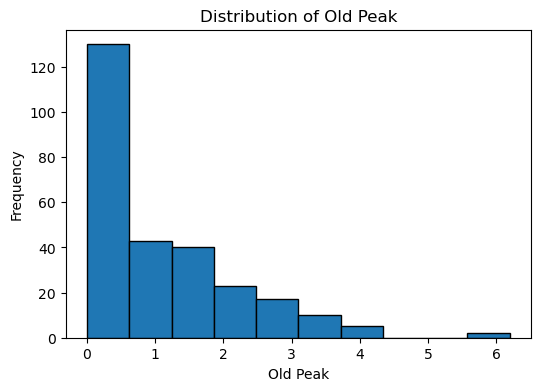

```python
# Draw histogram
plt.figure(figsize=(6, 4))
plt.hist(data['oldpeak'], bins=10, edgecolor='black')
plt.title('Distribution of Old Peak')
plt.xlabel('Old Peak')
plt.ylabel('Frequency')
plt.show()
```

```python
# Skewness test
skew(data['oldpeak'])
```

```
1.2558662822202507
```

The distribution for **oldpeak** is right-skewed, with all observations falling within a valid range and some outliers present. The **oldpeak** values range from 0 to 6.2, representing ST depression on an electrocardiogram (ECG) induced by exercise relative to rest. Higher values indicate a greater degree of underlying coronary artery disease, making values close to 0 typically preferred. Most patients in the dataset have an **oldpeak** value of less than 1.6.

### 'slope' Feature

```python
data['slope'].value_counts(normalize=True)
```

```
slope
1.0    0.481481
2.0    0.451852
3.0    0.066667
Name: proportion, dtype: float64
```

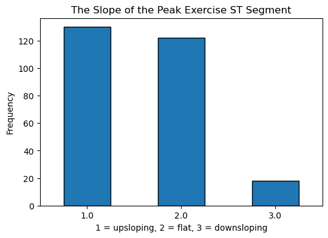

```python
plt.figure(figsize=(6, 4))
data['slope'].value_counts().plot(kind='bar', edgecolor='black')
plt.title('The Slope of the Peak Exercise ST Segment')
plt.xlabel('1 = upsloping, 2 = flat, 3 = downsloping')
plt.ylabel('Frequency')
plt.xticks(rotation=0)
plt.show()
```

The bar chart shows the distribution of the slope of the ST segment during peak exercise, categorized into three types:

- 1: the ST segment slopes upwards, considered normal
- 2: the ST segment remains flat, generally a sign of an underlying cardiac disease
- 3: the ST segment slopes downwards, associated with higher risks of coronary artery diseases

Most patients in the dataset have a normal upsloping ST segment, with those showing a flat ST segment, indicating signs of an underlying cardiac disease, close behind. The downsloping ST segment is the least common but is associated with the highest risk of coronary artery diseases.

### 'major-vessels' Feature

```python
data['major-vessels'].value_counts(normalize=True)
```

```
major-vessels
0.0    0.592593
1.0    0.214815
2.0    0.122222
3.0    0.070370
Name: proportion, dtype: float64
```

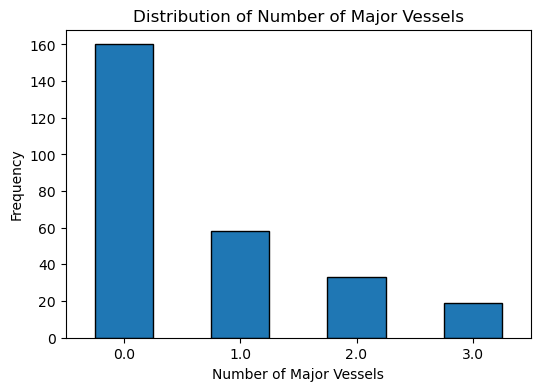

```python
plt.figure(figsize=(6, 4))
data['major-vessels'].value_counts().plot(kind='bar', edgecolor='black')
plt.title('Distribution of Number of Major Vessels')
plt.xlabel('Number of Major Vessels')
plt.ylabel('Frequency')
plt.xticks(rotation=0)
plt.show()
```

The bar chart shows the distribution of the number of **major vessels** with significant blockage in patients.

- 0: no coronary artery blockage.
- 1: one coronary artery blockage.
- 2: two coronary artery blockages.
- 3: three or more coronary artery blockages.

This distribution indicates that the majority of patients do not have any major vessels with significant blockage, while progressively fewer patients have one, two, or three or more major vessels blocked.

### 'thal' Feature

```python
data['thal'].value_counts(normalize=True)
```

```
thal
3.0    0.562963
7.0    0.385185
6.0    0.051852
Name: proportion, dtype: float64
```

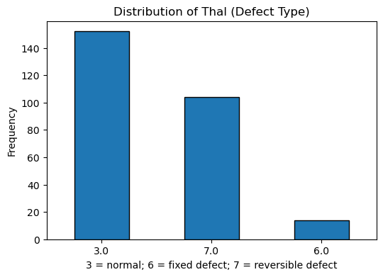

```python
plt.figure(figsize=(6, 4))
data['thal'].value_counts().plot(kind='bar', edgecolor='black')
plt.title('Distribution of Thal (Defect Type)')
plt.xlabel('3 = normal; 6 = fixed defect; 7 = reversible defect')
plt.ylabel('Frequency')
plt.xticks(rotation=0)
plt.show()
```

The bar chart shows the distribution of thal defect types in patients and refers to thalassemia, a blood disorder involving less than normal amounts of an oxygen-carrying protein. It is often used to diagnose coronary artery disease. The defect types are categorized as normal (3), fixed defect (6), and reversible defect (7).

- 3: indicates no defect
- 6: indicates a fixed defect, where a defect is present and remains unchanged
- 7: indicates a reversible defect, where a defect is present but can be reversed

Based on the bar chart, most patients do not have any thal defects, while some have reversible defects, and a smaller number have fixed defects.

### Target (heart-disease)

```python
data['heart-disease'].value_counts(normalize=True)
```

```
heart-disease
0    0.555556
1    0.444444
Name: proportion, dtype: float64
```

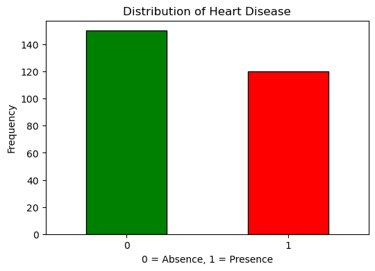

```python
plt.figure(figsize=(6, 4))
data['heart-disease'].value_counts().plot(kind='bar', color=['green', 'red'], edgecolor='black')
plt.title('Distribution of Heart Disease')
plt.xlabel('0 = Absence, 1 = Presence')
plt.ylabel('Frequency')
plt.xticks(rotation=0)
plt.show()
```

### Bivariate Analysis

Next, we examine the relationship between our quantitative feature variables. This analysis will help us understand how these variables are correlated with each other and identify any potential patterns or trends. We can use various methods such as scatter plots, correlation matrices, and pair plots to visualize and analyze these relationships. Additionally, we will calculate the Variance Inflation Factor (VIF) to detect multicollinearity among the variables, which can help us understand if any feature variables are highly correlated with each other.

```python
numerical_features = ['age', 'rest-bp', 'serum-chol', 'max-heart-rate', 'oldpeak']
```

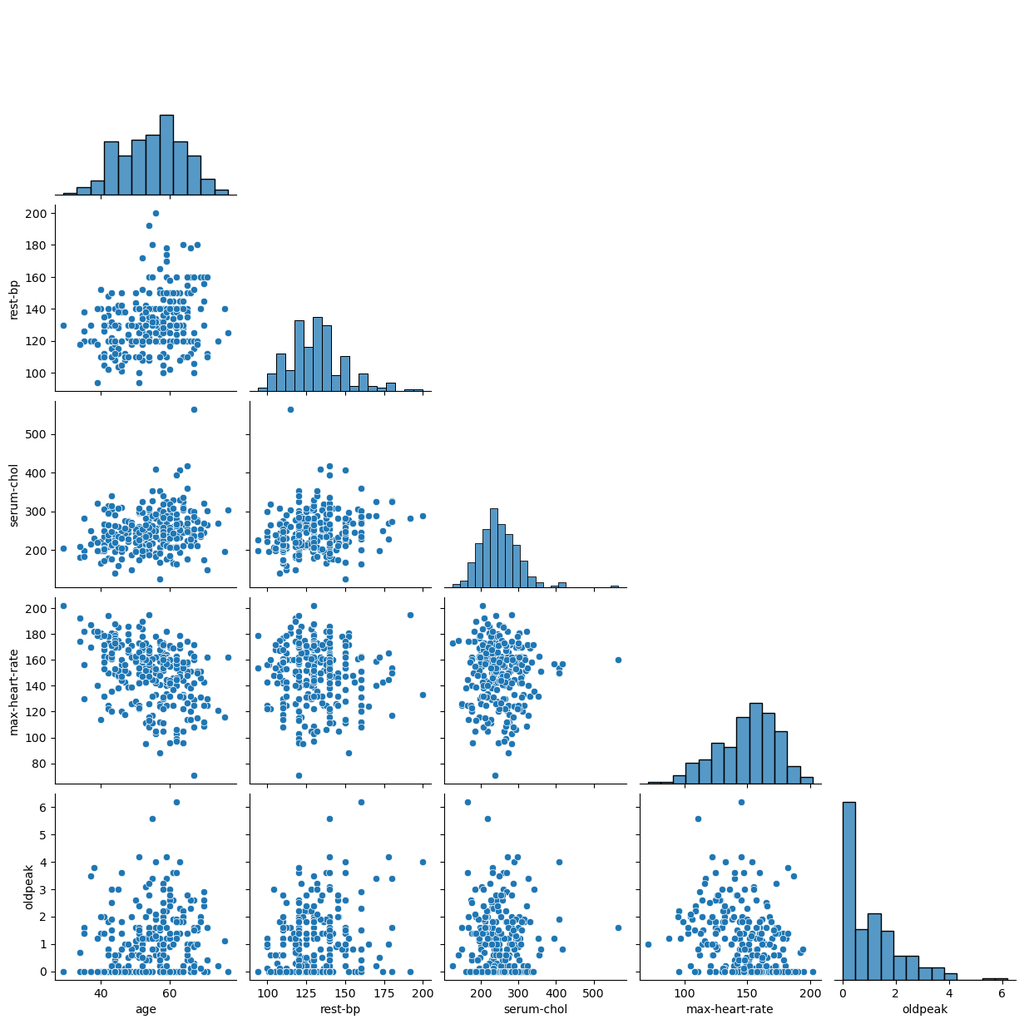

```python
# Pairwise scatterplot
sns.pairplot(data[numerical_features], corner=True)
plt.show()
```

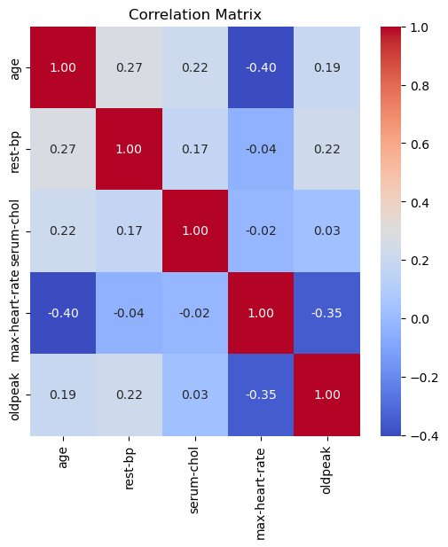

```python
# Heatmap displaying correlation coefficient
plt.figure(figsize=(6, 6))
correlation_matrix = data[numerical_features].corr()
sns.heatmap(correlation_matrix, annot=True, cmap='coolwarm', fmt='.2f')
plt.title('Correlation Matrix')
plt.show()
```

The pair plot and the correlation matrix reveal the presence of some moderate and weak correlations among the variables:

- **Age** and **Maximum Heart Rate**: there is a moderate negative correlation of -0.4, indicating that older patients tend to have lower maximum heart rates
- **Oldpeak** and **Maximum Heart Rate**: there is a negative correlation of -0.35, suggesting that higher oldpeak values (indicating more severe ST depression) are associated with lower maximum heart rates
- **Age** and **Resting BP**: there is a weak positive correlation of 0.27, suggesting that resting blood pressure tends to be slightly higher in older patients

```python
from statsmodels.tools.tools import add_constant

# add a constant term to the data to fit the intercept of the model
df_with_const = add_constant(data[numerical_features])

# calculate VIF for each feature
vif = pd.DataFrame()
vif["feature"] = df_with_const.columns
vif["VIF"] = [variance_inflation_factor(df_with_const.values, i) for i in range(df_with_const.shape[1])]

vif
```

|  | feature | VIF |
| --- | --- | --- |
| 0 | const | 166.282898 |
| 1 | age | 1.346324 |
| 2 | rest-bp | 1.155639 |
| 3 | serum-chol | 1.071767 |
| 4 | max-heart-rate | 1.344857 |
| 5 | oldpeak | 1.198864 |

VIF analysis indicates that multicollinearity is not a significant concern as the VIF values of the numerical features are relatively low, all being less than 2.

### Identifying Multidimensional Outliers Using Mahalanobis Distance

We then identify the presence of outliers in multidimensional space using the Mahalanobis distance.

```python
# Calculate the mean and covariance matrix on the scaled data
mean = np.mean(data[numerical_features], axis=0)
cov = np.cov(data[numerical_features], rowvar=False)
inv_covmat = np.linalg.inv(cov)

# Calculate Mahalanobis distance for each observation
def mahalanobis_distance(row, mean, inv_covmat):
    diff = row - mean
    return np.sqrt(np.dot(np.dot(diff, inv_covmat), diff.T))

data['mahalanobis'] = pd.DataFrame(data[numerical_features], columns=numerical_features).apply(lambda row: mahalanobis_distance(row, mean, inv_covmat), axis=1)

# Determine the threshold for the 99% confidence interval
threshold = chi2.ppf(0.99, len(numerical_features))

# Identify outliers (note: using np.sqrt(threshold) for the distance)
outliers = data[data['mahalanobis'] > np.sqrt(threshold)]

# Print the outliers DataFrame
print("Outliers:")
display(outliers)
```

```
Outliers:
```

|  | age | sex | chest-pain | rest-bp | serum-chol | fasting-blood-sugar | electrocardiographic | max-heart-rate | angina | oldpeak | slope | major-vessels | thal | heart-disease | mahalanobis |
| --- | --- | --- | --- | --- | --- | --- | --- | --- | --- | --- | --- | --- | --- | --- | --- |
| 1 | 67.0 | 0.0 | 3.0 | 115.0 | 564.0 | 0.0 | 2.0 | 160.0 | 0.0 | 1.6 | 2.0 | 0.0 | 7.0 | 0 | 6.549626 |
| 9 | 63.0 | 0.0 | 4.0 | 150.0 | 407.0 | 0.0 | 2.0 | 154.0 | 0.0 | 4.0 | 2.0 | 3.0 | 7.0 | 1 | 4.119912 |
| 117 | 56.0 | 0.0 | 4.0 | 200.0 | 288.0 | 1.0 | 2.0 | 133.0 | 1.0 | 4.0 | 3.0 | 2.0 | 7.0 | 1 | 4.424887 |
| 144 | 54.0 | 1.0 | 2.0 | 192.0 | 283.0 | 0.0 | 2.0 | 195.0 | 0.0 | 0.0 | 1.0 | 1.0 | 7.0 | 1 | 4.129576 |
| 156 | 55.0 | 1.0 | 4.0 | 140.0 | 217.0 | 0.0 | 0.0 | 111.0 | 1.0 | 5.6 | 3.0 | 0.0 | 7.0 | 1 | 4.122088 |
| 235 | 62.0 | 0.0 | 4.0 | 160.0 | 164.0 | 0.0 | 2.0 | 145.0 | 0.0 | 6.2 | 3.0 | 3.0 | 7.0 | 1 | 5.180037 |

The Mahalanobis distance identified the presence of 6 outliers in multidimensional space. Given that we only have 270 observations in our dataset, removing these outliers would reduce the variation present within our data. Therefore, we choose to retain the outliers to preserve the dataset’s diversity.

```python
data = data.drop(columns=["mahalanobis"])
```

## Feature Selection

Now, we will carry out feature selection on the cleaned dataset using the ReliefF and FCBF algorithms.

First, we define our numerical and categorical columns. Next, we split the data into features (X) and target (y). We then standardize the numerical variables since they are measured on different scales. This process ensures uniformity and improves data quality. Without standardization, our results could be compromised.

```python
# Identify numerical and categorical columns
numerical_columns = ['age', 'rest-bp', 'serum-chol', 'max-heart-rate', 'oldpeak']
categorical_columns = ['sex', 'chest-pain', 'fasting-blood-sugar', 'electrocardiographic', 'angina', 'slope', 'thal', 'major-vessels']

# Split the dataset
X = data.drop(columns=['heart-disease'])
y = data['heart-disease']

# Normalize numerical data
scaler = StandardScaler()
X[numerical_columns] = scaler.fit_transform(X[numerical_columns])
```

Finally, we split the data into training and testing sets using a 75/25 ratio. We then use the training dataset to rank the features based on their importance.

```python
from sklearn.model_selection import train_test_split

# Split training and testing data
X_train, X_test, y_train, y_test = train_test_split(X, y, test_size=0.25, random_state=101)

# Convert the DataFrame to a NumPy array
X_train_np = X_train.values
X_test_np = X_test.values
```

### ReliefF

ReliefF is a type of feature weighting algorithm based on the Relief method. The key idea of ReliefF is to estimate the relevance of features by assessing how well their values differentiate between instances of the same and different classes that are near each other. The algorithm randomly samples a number (m) of instances from the training set and updates the relevance estimation of each feature based on the difference between the selected instance and the two nearest instances of the same and opposite classes. We implement the ReliefF algorithm using the ReliefF function from the skrebate package. In this implementation, we set the number of nearest neighbors to 5 to obtain the feature rankings. This function helps us rank the features based on their relevance as determined by the ReliefF algorithm.

```python
from skrebate import ReliefF

# Apply ReliefF with Ranker search method and 5 nearest neighbors
relieff = ReliefF(n_neighbors=5, n_features_to_select=X_train_np.shape[1])
relieff.fit(X_train_np, y_train.values)

# Get the feature importance scores
relief_scores = relieff.feature_importances_

# Create a DataFrame for the features and their ReliefF scores
features_list = X_train.columns.tolist()
feature_ranks = sorted(zip(features_list, relief_scores), key=lambda x: x[1], reverse=True)
relief_df = pd.DataFrame(feature_ranks, columns=['Feature', 'Score'])

# Display the DataFrame
print(relief_df)
```

```
                 Feature     Score
0          major-vessels  0.184158
1                   thal  0.162376
2             chest-pain  0.157426
3                    sex  0.133663
4                rest-bp  0.060120
5                    age  0.055031
6                  slope  0.047525
7             serum-chol  0.043998
8   electrocardiographic  0.039604
9                oldpeak  0.037959
10                angina  0.032673
11        max-heart-rate  0.030927
12   fasting-blood-sugar  0.014851
```

From the results of ReliefF, we determine the five most important features to predict heart disease to be major vessels, thalassemia, chest pain, sex, and resting blood pressure. The three least important features are exercise-induced angina, maximum heart rate, and fasting blood sugar.

A drawback of ReliefF is that it does not help with removing redundant features. Redundant features can negatively affect the speed and accuracy of learning algorithms and should be eliminated. To address this, we can use additional feature selection methods, such as the Fast Correlation-Based Filter (FCBF), which specifically targets and removes redundant features.

### Fast Correlation-Based Filter (FCBF)

Next, we perform feature selection using the Fast Correlation-Based Filter (FCBF). FCBF is another feature weighting algorithm based on a correlation-based measure that evaluates the relevance and redundancy of features. Unlike ReliefF, which does not filter out redundant features, FCBF aims to identify and remove these redundancies to enhance the performance of the learning algorithm.

FCBF utilizes entropy and Information Gain (IG) to measure the relevance of features. The symmetrical uncertainty is then used to assess the redundancy between features.

Entropy measures the uncertainty or randomness in a dataset and is used to calculate Information Gain (IG), which identifies the most informative features by measuring the reduction in entropy when the dataset is split. Symmetrical Uncertainty normalizes IG to account for the entropy of both the feature and the target, helping to assess feature redundancy. To implement FCBF, we need to define functions to calculate entropy and symmetrical uncertainty.

```python
from sklearn.feature_selection import mutual_info_classif

def entropy(x):
    """ Calculate entropy of a variable """
    _, counts = np.unique(x, return_counts=True)
    probs = counts / len(x)
    return -np.sum(probs * np.log2(probs))

def symmetrical_uncertainty(X, y):
    """ Calculate the Symmetrical Uncertainty """
    su_scores = []
    hy = entropy(y)
    for i in range(X.shape[1]):
        hx = entropy(X[:, i])
        ig = mutual_info_classif(X[:, i].reshape(-1, 1), y, discrete_features=True)
        su = 2 * (ig / (hx + hy))
        su_scores.append(su[0])
    return np.array(su_scores)
```

Since symmetrical uncertainty requires features to be discrete, we next discretize our continuous variables. Discretization transforms continuous variables into discrete bins, making them suitable for calculating symmetrical uncertainty.

```python
# Bin continuous variables to make them discrete
for col in numerical_columns:
    X_train[col] = pd.cut(X_train[col], bins=10, labels=False)
    X_test[col] = pd.cut(X_test[col], bins=10, labels=False)
```

```python
from skfeature.function.information_theoretical_based import FCBF

# Apply FCBF
selected_features = FCBF.fcbf(X_train.values, y_train.values)

# Calculate Symmetrical Uncertainty for the selected features
su_scores = symmetrical_uncertainty(X_train.values[:, selected_features], y_train.values)

# Create a DataFrame for the selected features and their SU scores
selected_features_list = X_train.columns[selected_features].tolist()
feature_ranks = sorted(zip(selected_features_list, su_scores), key=lambda x: x[1], reverse=True)
fcbf_df = pd.DataFrame(feature_ranks, columns=['Feature', 'Score'])

# Display the DataFrame
print(fcbf_df)
```

```
                 Feature     Score
0                   thal  0.139179
1             chest-pain  0.110105
2          major-vessels  0.108558
3                 angina  0.088256
4                  slope  0.054425
5         max-heart-rate  0.048932
6                oldpeak  0.045839
7                    sex  0.040054
8                    age  0.021985
9   electrocardiographic  0.013190
10            serum-chol  0.011430
11               rest-bp  0.011029
12   fasting-blood-sugar  0.000285
```

From the FCBF results, the five most crucial features for predicting heart disease are identified as thalassemia, chest pain, major vessels, angina, and slope. The three features with the least significance are serum cholesterol, resting blood pressure, and fasting blood sugar.

Interestingly, both algorithms agree on the top three features, although there are discrepancies in the importance rankings of some features. For instance, a top feature in one algorithm may be considered less important in the other, and vice versa. Due to these differences, we will take the union of the top six features selected by each algorithm to form the final subset of important features.

```python
features_subset = list(pd.merge(relief_df.iloc[:6], fcbf_df.iloc[:6], how='outer', on='Feature')['Feature'].unique())
features_subset
```

```
['age',
 'angina',
 'chest-pain',
 'major-vessels',
 'max-heart-rate',
 'rest-bp',
 'sex',
 'slope',
 'thal']
```

```python
heart_disease_subset = data[features_subset].join(y)
heart_disease_subset.to_csv("heart_disease_subset.csv", index=False)
```